# FLOW

Francesco Cabras

21 April 2020

```r
D <- read.csv("DAT.csv")
```

Simple linear model.

```r
LM <- lm(log(PRI) ~ log(GAS) + DEP + log(CON) + INF + REN + log(GDP) + log(OIL) + MAR, D)
summary(LM)
```

```
##
## Call:
## lm(formula = log(PRI) ~ log(GAS) + DEP + log(CON) + INF + REN +
##     log(GDP) + log(OIL) + MAR, data = D)
##
## Residuals:
##      Min       1Q   Median       3Q      Max
## -1.08020 -0.13512  0.01452  0.14262  0.71677
##
## Coefficients:
##               Estimate Std. Error t value Pr(>|t|)
## (Intercept) -4.840e+00  1.243e-01 -38.939  < 2e-16 ***
## log(GAS)     2.279e-01  2.732e-02   8.339  < 2e-16 ***
## DEP          2.129e-05  6.628e-05   0.321  0.74816
## log(CON)    -6.245e-02  2.110e-02  -2.959  0.00314 **
## INF          1.815e-03  6.621e-04   2.741  0.00621 **
## REN         -5.280e-03  5.591e-04  -9.444  < 2e-16 ***
## log(GDP)     2.398e-01  1.416e-02  16.936  < 2e-16 ***
## log(OIL)     1.035e-01  1.571e-02   6.587 6.65e-11 ***
## MAR         -1.609e-03  2.556e-04  -6.293 4.34e-10 ***
## ---
## Signif. codes:  0 '***' 0.001 '**' 0.01 '*' 0.05 '.' 0.1 ' ' 1
##
## Residual standard error: 0.212 on 1222 degrees of freedom
## Multiple R-squared:  0.5779, Adjusted R-squared:  0.5751
## F-statistic: 209.1 on 8 and 1222 DF,  p-value: < 2.2e-16
```

We may want to use part of the geographical information by including a dummy variable that indicates the belonging to the European Union (i.e. being one of the 28 member countries).

```r
for (row in 1:nrow(D)) {
  if (as.character(D[row, "geo"]) %in% c("BE", "EL", "LT", "PT", "BG", "ES", "LU", "RO", "CZ", "FR", "HU", "SI", "DK", "HR", "MT", "SK", "DE", "IT", "NL", "FI", "EE", "CY", "AT", "SE", "IE", "LV", "PL", "UK")) {
    D$EU[row] <- 1
  }
  else { D$EU[row] <- 0 }
}


LMe <- lm(log(PRI) ~ log(GAS) + DEP + log(CON) + INF + REN + log(GDP) + log(OIL) + MAR + EU, D)
summary(LMe)
```

```
##
## Call:
## lm(formula = log(PRI) ~ log(GAS) + DEP + log(CON) + INF + REN +
##     log(GDP) + log(OIL) + MAR + EU, data = D)
##
## Residuals:
##      Min       1Q   Median       3Q      Max
## -0.99249 -0.13471  0.00822  0.14705  0.69514
##
## Coefficients:
##               Estimate Std. Error t value Pr(>|t|)
## (Intercept) -4.783e+00  1.222e-01 -39.143  < 2e-16 ***
## log(GAS)     2.205e-01  2.682e-02   8.222 5.06e-16 ***
## DEP         -1.459e-04  6.923e-05  -2.108   0.0352 *
## log(CON)    -8.163e-02  2.088e-02  -3.910 9.75e-05 ***
## INF          2.671e-03  6.607e-04   4.043 5.62e-05 ***
## REN         -4.111e-03  5.731e-04  -7.174 1.26e-12 ***
## log(GDP)     2.224e-01  1.410e-02  15.765  < 2e-16 ***
## log(OIL)     1.002e-01  1.541e-02   6.499 1.18e-10 ***
## MAR         -1.268e-03  2.554e-04  -4.964 7.89e-07 ***
## EU           1.506e-01  2.144e-02   7.021 3.64e-12 ***
## ---
## Signif. codes:  0 '***' 0.001 '**' 0.01 '*' 0.05 '.' 0.1 ' ' 1
##
## Residual standard error: 0.2079 on 1221 degrees of freedom
## Multiple R-squared:  0.5943, Adjusted R-squared:  0.5913
## F-statistic: 198.7 on 9 and 1221 DF,  p-value: < 2.2e-16
```

Also dependency becomes significant when we control for EU belonging.

```r
DP <- D

for (row in 1:nrow(DP)) {
  if (as.character(DP[row, "geo"]) %in% c("BG", "RO", "CZ", "HU", "HR", "SE", "DK", "PL", "UK")) {
    DP$EU[row] <- "EU"
}
  else if (as.character(DP[row, "geo"]) %in% c("NO", "IS", "LI")) {
    DP$EU[row] <- "EFTA"
  }
  else if (as.character(DP[row, "geo"]) %in% c("BE", "EL", "LT", "PT", "ES", "LU", "FR", "SI", "MT", "SK", "DE", "IT", "NL", "FI", "EE", "CY", "AT", "IE", "LV")){
    DP$EU[row] <- "EA"
    }
}
rm(row)

DP$EU <- as.factor(DP$EU)
LMeP <- lm(log(PRI) ~ log(GAS) + DEP + log(CON) + INF + REN + log(GDP) + log(OIL) + MAR + EU, DP)
summary(LMeP)
```

```
##
## Call:
## lm(formula = log(PRI) ~ log(GAS) + DEP + log(CON) + INF + REN +
##     log(GDP) + log(OIL) + MAR + EU, data = DP)
##
## Residuals:
##      Min       1Q   Median       3Q      Max
## -0.95580 -0.12891  0.00454  0.13755  0.67390
##
## Coefficients:
##               Estimate Std. Error t value Pr(>|t|)
## (Intercept) -4.652e+00  1.210e-01 -38.434  < 2e-16 ***
## log(GAS)     2.202e-01  2.626e-02   8.383  < 2e-16 ***
## DEP          1.343e-04  8.055e-05   1.668  0.09564 .
## log(CON)    -6.617e-02  2.085e-02  -3.174  0.00154 **
## INF          3.580e-03  6.585e-04   5.436 6.59e-08 ***
## REN         -5.313e-03  5.845e-04  -9.089  < 2e-16 ***
## log(GDP)     1.794e-01  1.532e-02  11.705  < 2e-16 ***
## log(OIL)     9.949e-02  1.509e-02   6.594 6.35e-11 ***
## MAR         -1.483e-03  2.621e-04  -5.656 1.92e-08 ***
## EUEA         2.353e-01  2.438e-02   9.650  < 2e-16 ***
## EUEFTA       3.709e-01  5.127e-02   7.235 8.24e-13 ***
## EUEU         2.016e-01  2.428e-02   8.305 2.63e-16 ***
## ---
## Signif. codes:  0 '***' 0.001 '**' 0.01 '*' 0.05 '.' 0.1 ' ' 1
##
## Residual standard error: 0.2034 on 1219 degrees of freedom
## Multiple R-squared:  0.6123, Adjusted R-squared:  0.6088
## F-statistic:   175 on 11 and 1219 DF,  p-value: < 2.2e-16
```

To be checked: - residuals sum to zero - no autocorrelation for residuals - no perfect multicollinearity - homoskedasticity

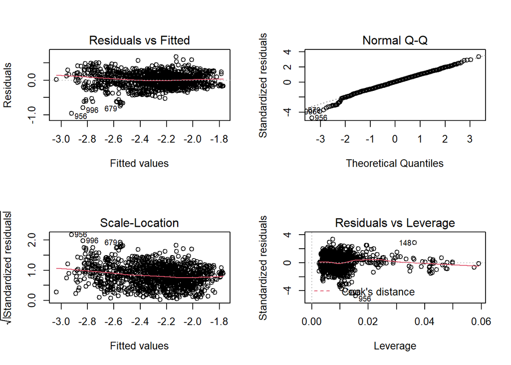

```r
par(mfrow = c(2, 2))
plot(LMeP)
```

What happens with observation 956 and 996?

```r
D[c(956,996),]
```

|  | time | geo | PRI | GAS | DEP | CON | INF | EMI | MAR | REN | GDP | OIL | EU |
| --- | --- | --- | --- | --- | --- | --- | --- | --- | --- | --- | --- | --- | --- |
| 956 | 2016.0 | UA | 0.0207 | 4.2 | 29.3 | 545 | 99.16 | 86.1 | 56.1 | 24 | 1690 | 33.62 | 0 |
| 996 | 2016.5 | UA | 0.0267 | 5.5 | 33.1 | 546 | 100.33 | 85.6 | 54.5 | 24 | 1693 | 41.60 | 0 |

Price is very low because Ukraine may be considered as a not yet very developed country where, also, energy is very easily obtainable. Nothing too weird here, we do not consider them as outliers.

```r
lawstat::runs.test(LMeP$residuals)
```

```
##
##  Runs Test - Two sided
##
## data:  LMeP$residuals
## Standardized Runs Statistic = 1.4542, p-value = 0.1459
```

There seems to be no problem with autocorrelation of residuals.

```r
vif(LMeP)
```

```
##              GVIF Df GVIF^(1/(2*Df))
## log(GAS) 2.547856  1        1.596201
## DEP      2.903212  1        1.703881
## log(CON) 2.504039  1        1.582416
## INF      1.685502  1        1.298269
## REN      2.403682  1        1.550381
## log(GDP) 4.034784  1        2.008677
## log(OIL) 1.369391  1        1.170210
## MAR      1.264038  1        1.124295
## EU       6.913855  3        1.380236
```

Variance Inflator Formula also ok.

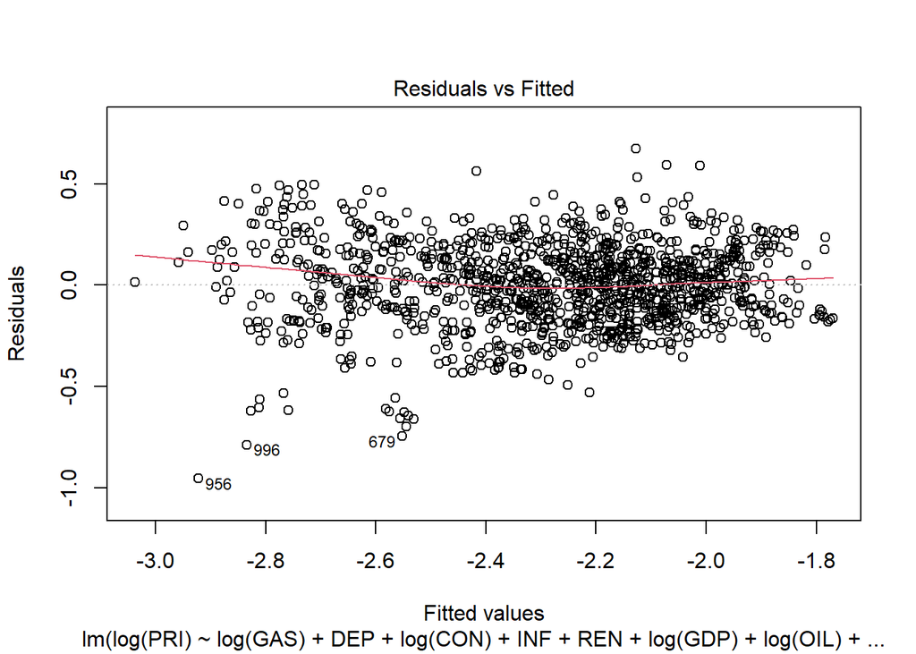

```r
plot(LMeP,1)
```

To try to solve it, box-cox transformation of the dependent variable does not solve the problem.

```r
S <- DP
U <- caret::BoxCoxTrans(S$PRI)
S <- cbind(S, nP=predict(U, S$PRI))
LMeB <- lm(nP ~ log(GAS) + DEP + log(CON) + INF + REN + log(GDP) + log(OIL) + MAR + EU, S)
bptest(LMeB)
```

```
##
##  studentized Breusch-Pagan test
##
## data:  LMeB
## BP = 148.97, df = 11, p-value < 2.2e-16
```

```r
rm(S, U)
```

Still heteroskedasticity detected. Let us deviate from ordinary least squares to use a weighted least squares model.

```r
DP$resi <- LMeP$residuals
LMeR <- lm(log(resi^2) ~ log(GAS) + DEP + log(CON) + INF + REN + log(GDP) + log(OIL) + MAR + EU, DP)

DP$varFunc <- exp(LMeR$fitted.values)
LMgls <- lm(log(PRI) ~ log(GAS) + DEP + log(CON) + INF + REN + log(GDP) + log(OIL) + MAR + EU, weights = 1/sqrt(varFunc), DP)
summary(LMgls)
```

```
##
## Call:
## lm(formula = log(PRI) ~ log(GAS) + DEP + log(CON) + INF + REN +
##     log(GDP) + log(OIL) + MAR + EU, data = DP, weights = 1/sqrt(varFunc))
##
## Weighted Residuals:
##      Min       1Q   Median       3Q      Max
## -2.54880 -0.40322  0.00679  0.42907  2.29985
##
## Coefficients:
##               Estimate Std. Error t value Pr(>|t|)
## (Intercept) -4.683e+00  1.184e-01 -39.569  < 2e-16 ***
## log(GAS)     2.610e-01  2.423e-02  10.773  < 2e-16 ***
## DEP         -2.260e-05  5.737e-05  -0.394   0.6937
## log(CON)    -5.147e-02  2.102e-02  -2.448   0.0145 *
## INF          4.502e-03  6.218e-04   7.240 7.94e-13 ***
## REN         -6.451e-03  5.118e-04 -12.606  < 2e-16 ***
## log(GDP)     1.600e-01  1.403e-02  11.406  < 2e-16 ***
## log(OIL)     7.393e-02  1.388e-02   5.326 1.19e-07 ***
## MAR         -1.007e-03  2.456e-04  -4.101 4.38e-05 ***
## EUEA         2.645e-01  2.681e-02   9.865  < 2e-16 ***
## EUEFTA       3.967e-01  4.329e-02   9.164  < 2e-16 ***
## EUEU         2.315e-01  2.651e-02   8.732  < 2e-16 ***
## ---
## Signif. codes:  0 '***' 0.001 '**' 0.01 '*' 0.05 '.' 0.1 ' ' 1
##
## Residual standard error: 0.5801 on 1219 degrees of freedom
## Multiple R-squared:  0.6299, Adjusted R-squared:  0.6266
## F-statistic: 188.6 on 11 and 1219 DF,  p-value: < 2.2e-16
```

```r
rm(LMeR)
```

Let us now proceed with a coefficients’ comparison between LMeP and LMgls.

```r
print("Coefficients LM")
```

```
## [1] "Coefficients LM"
```

```r
coef(LMeP)
```

```
##   (Intercept)      log(GAS)           DEP      log(CON)           INF
## -4.6519227409  0.2201734959  0.0001343297 -0.0661708903  0.0035796637
##           REN      log(GDP)      log(OIL)           MAR          EUEA
## -0.0053129120  0.1793635530  0.0994941213 -0.0014826698  0.2352935364
##        EUEFTA          EUEU
##  0.3708877500  0.2016103192
```

```r
print("Coefficients weighted regressions")
```

```
## [1] "Coefficients weighted regressions"
```

```r
coef(LMgls)
```

```
##   (Intercept)      log(GAS)           DEP      log(CON)           INF
## -4.683103e+00  2.609984e-01 -2.260199e-05 -5.146744e-02  4.501995e-03
##           REN      log(GDP)      log(OIL)           MAR          EUEA
## -6.451335e-03  1.600216e-01  7.393169e-02 -1.007393e-03  2.645195e-01
##        EUEFTA          EUEU
##  3.967333e-01  2.315233e-01
```

Subset selection. We want to maximize adjusted R squared and minimize cp and bic.

```r
library(leaps)
LM3 <- regsubsets(log(PRI) ~ log(GAS) + DEP + log(CON) + INF + REN + log(GDP) + log(OIL) + MAR + EU, DP, nvmax = 12)
which.max(summary(LM3)$adjr2)
```

```
## [1] 11
```

```r
which.min(summary(LM3)$bic)
```

```
## [1] 10
```

```r
which.min(summary(LM3)$cp)
```

```
## [1] 11
```

```r
train <- (DP$time < 2015)
test <- (!train)
```

Simple linear regression on train now. To compare accuracies of models we are going to use Mean Absolute Error (for interpretability reasons). Since our dependent variable is measured on a log scale we have to have to exponentiate prediction vectors.

```r
LMeP <- lm(log(PRI) ~ log(GAS) + DEP + log(CON) + INF + REN + log(GDP) + log(OIL) + MAR + EU, DP, subset=train)
pred <- predict(LMeP, DP[test,])
mean(abs(DP$PRI[test] - exp(pred)))
```

```
## [1] 0.0164706
```

Performance, instead, with weighted regression.

```r
DP$resi[train] <- LMeP$residuals
LMeR <- lm(log(resi^2) ~ log(GAS) + DEP + log(CON) + INF + REN + log(GDP) + log(OIL) + MAR + EU, DP, subset=train)

DP$varFunc[train] <- exp(LMeR$fitted.values)
LMgls <- lm(log(PRI) ~ log(GAS) + DEP + log(CON) + INF + REN + log(GDP) + log(OIL) + MAR + EU, weights = 1/sqrt(varFunc), DP, subset=train)
pred <- predict(LMgls, DP[test,])
mean(abs(DP$PRI[test] - exp(pred)))
```

```
## [1] 0.01634735
```

```r
rm(LMeR)
```

Performance better with weighted regression, confirming our hypothesis that ordinary least squares in this context may not be optimal.

```r
W <- 1/sqrt(DP$varFunc[train])
tLM <- regsubsets(log(PRI) ~ log(GAS) + DEP + log(CON) + INF + REN + log(GDP) + log(OIL) + MAR + EU, DP[train,], weights=W, nvmax = 11)
test.mat <- model.matrix(log(PRI) ~ log(GAS) + DEP + log(CON) + INF + REN + log(GDP) + log(OIL) + MAR + EU, data=DP[test,])
val.errors <- rep(NA, 11)
for (i in 1:11){
  coefi <- coef(tLM, id=i)
  pred <- test.mat[,names(coefi)] %*% coefi
  val.errors[i] <- mean(abs(DP$PRI[test] - exp(pred)))
}
which.min(val.errors)
```

```
## [1] 9
```

```r
val.errors[which.min(val.errors)]
```

```
## [1] 0.01622239
```

```r
coef(tLM, which.min(val.errors))
```

```
##  (Intercept)     log(GAS)          INF          REN     log(GDP)     log(OIL)
## -4.756725929  0.220256274  0.004363149 -0.008526025  0.132609054  0.119695355
##          MAR         EUEA       EUEFTA         EUEU
## -0.001581629  0.218737980  0.477785402  0.166515182
```

Now, time for ridge regression.

```r
x <- model.matrix(log(PRI) ~ log(GAS) + DEP + log(CON) + INF + REN + log(GDP) + log(OIL) + MAR + EU, DP)[,-1]
y <- DP$PRI
set.seed(35)
ridge <- cv.glmnet(x[train,], log(y[train]), alpha=0, weights=W, standardize=T)
bestlam <- min(ridge$lambda)
```

What is the test average difference between the prediction and the actual price of electricity?

```r
ridge.pred <- predict(ridge, s=bestlam, newx=x[test,])
mean(abs(exp(ridge.pred) - y[test]))
```

```
## [1] 0.01657408
```

Coefficients.

```r
predict(ridge, type="coefficients", s=bestlam)
```

```
## 12 x 1 sparse Matrix of class "dgCMatrix"
##                         1
## (Intercept) -4.456326e+00
## log(GAS)     1.858748e-01
## DEP         -1.744308e-05
## log(CON)    -4.166767e-02
## INF          4.525970e-03
## REN         -6.894306e-03
## log(GDP)     1.541791e-01
## log(OIL)     1.047365e-01
## MAR         -1.542353e-03
## EUEA         1.005183e-01
## EUEFTA       2.546658e-01
## EUEU         4.759882e-02
```

Time for lasso.

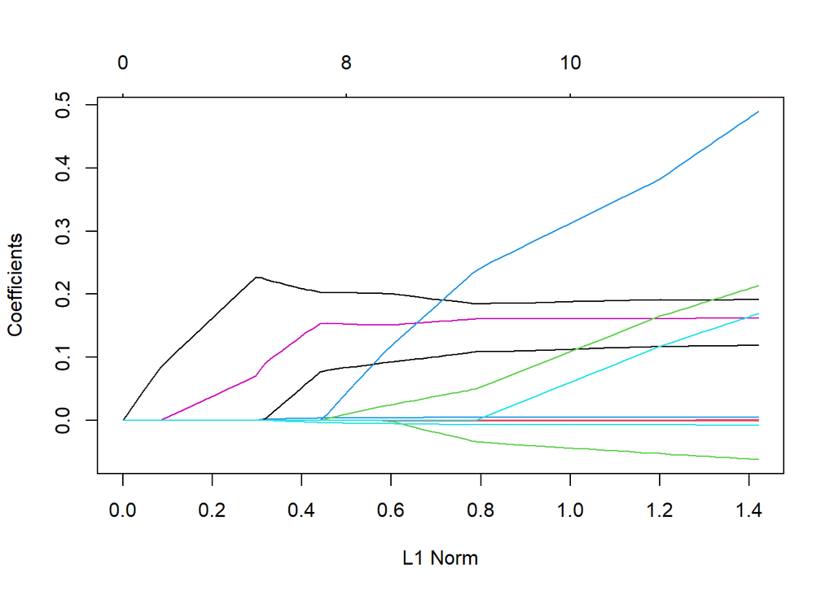

```r
lasso.mod <- glmnet(x[train,], log(y[train]), alpha=1, weights=W)
plot(lasso.mod)
```

Let us look for the best value of the parameter lambda (shrinkage).

```r
set.seed(35)
cv.out <- cv.glmnet(x[train,], sqrt(y[train]), alpha=1, weights=W)
bestlam <- cv.out$lambda.min
pred <- predict(lasso.mod, s=bestlam, newx=x[test,])
mean(abs(exp(pred) - y[test]))
```

```
## [1] 0.01632833
```

How many features is the model including?

```r
C <- as.vector(coef(cv.out, bestlam))
length(C[C != 0])
```

```
## [1] 12
```

All features are kept in the model.

This looks like a good result, however, interactions and polynomials of the variables were not taken into consideration.

Model selection with interactions. This time we start from no weights.

```r
LMeQ <- lm(log(PRI) ~ (log(GAS) + DEP + log(CON) + INF + REN + log(GDP) + log(OIL) + MAR)^2 + EU, DP, subset=train)
DP$resi[train] <- LMeQ$residuals
LMeR <- lm(log(resi^2) ~ (log(GAS) + DEP + log(CON) + INF + REN + log(GDP) + log(OIL) + MAR)^2 + EU, DP, subset=train)

DP$varFunc[train] <- exp(LMeR$fitted.values)
rm(LMeR)

W <- 1/sqrt(DP$varFunc[train])

tLM <- regsubsets(log(PRI) ~ (log(GAS) + DEP + log(CON) + INF + REN + log(GDP) + log(OIL) + MAR)^2 + EU, DP[train,], nvmax = 30, really.big = T, weights=W)

test.mat <- model.matrix(log(PRI) ~ (log(GAS) + DEP + log(CON) + INF + REN + log(GDP) + log(OIL) + MAR)^2 + EU, data=DP[test,])

val.errors <- rep(NA, 30)
for (i in 1:30){
  coefi <- coef(tLM, id=i)
  pred <- test.mat[,names(coefi)] %*% coefi
  val.errors[i] <- mean(abs(DP$PRI[test] - exp(pred)))
}
which.min(val.errors)
```

```
## [1] 20
```

```r
val.errors[which.min(val.errors)]
```

```
## [1] 0.01526082
```

```r
coef(tLM, which.min(val.errors))
```

```
##       (Intercept)          log(GAS)               DEP          log(CON)
##     -1.432089e+01     -3.228115e+00      2.393418e-02      1.810227e+00
##               REN          log(GDP)          log(OIL)               MAR
##      8.132728e-02      1.286812e+00      1.096516e+00     -1.365957e-02
##              EUEA            EUEFTA              EUEU log(GAS):log(CON)
##      1.377038e-01      4.458811e-01      1.828860e-01      4.326185e-01
## log(GAS):log(GDP)      DEP:log(CON)           DEP:REN           DEP:MAR
##      8.805555e-02     -3.307729e-03     -4.786056e-05      3.689939e-05
##      log(CON):REN log(CON):log(GDP) log(CON):log(OIL)           INF:MAR
##     -1.431100e-02     -2.089036e-01     -1.613984e-01      8.086143e-05
##           REN:MAR
##      1.643687e-04
```

```r
LMeQ <- lm(log(PRI) ~ poly(log(GAS),2) + poly(DEP,2) + poly(log(CON),2) + poly(INF,2) + poly(REN,2) + poly(log(GDP),2) + poly(log(OIL),2) + poly(MAR,2) + EU, DP, subset=train)
DP$resi[train] <- LMeQ$residuals
LMeR <- lm(log(PRI) ~ poly(log(GAS),2) + poly(DEP,2) + poly(log(CON),2) + poly(INF,2) + poly(REN,2) + poly(log(GDP),2) + poly(log(OIL),2) + poly(MAR,2) + EU, DP, subset=train)

DP$varFunc[train] <- exp(LMeR$fitted.values)
rm(LMeR)

W <- 1/sqrt(DP$varFunc[train])

tLM <- regsubsets(log(PRI) ~ poly(log(GAS),2) + poly(DEP,2) + poly(log(CON),2) + poly(INF,2) + poly(REN,2) + poly(log(GDP),2) + poly(log(OIL),2) + poly(MAR,2) + EU, DP[train,], nvmax = 18, weights=W)

test.mat <- model.matrix(log(PRI) ~ poly(log(GAS),2) + poly(DEP,2) + poly(log(CON),2) + poly(INF,2) + poly(REN,2) + poly(log(GDP),2) + poly(log(OIL),2) + poly(MAR,2) + EU, data=DP[test,])

val.errors <- rep(NA, 18)
for (i in 1:18){
  coefi <- coef(tLM, id=i)
  pred <- test.mat[,names(coefi)] %*% coefi
  val.errors[i] <- mean(abs(DP$PRI[test] - exp(pred)))
}
which.min(val.errors)
```

```
## [1] 1
```

```r
val.errors[which.min(val.errors)]
```

```
## [1] 0.01998005
```

```r
coef(tLM, which.min(val.errors))
```

```
##        (Intercept) poly(log(GDP), 2)1
##          -2.303169           5.248570
```

```r
x <- model.matrix(log(PRI) ~ poly(log(GAS),2) + poly(DEP,2) + poly(log(CON),2) + poly(INF,2) + poly(REN,2) + poly(log(GDP)) + poly(log(OIL),2) + poly(MAR,2)^2 + EU, DP)[,-1]
lasso.mod <- glmnet(x[train,], log(y[train]), alpha=1)

set.seed(35)
cv.out <- cv.glmnet(x[train,], sqrt(y[train]), alpha=1)
bestlam <- cv.out$lambda.min
pred <- predict(lasso.mod, s=bestlam, newx=x[test,])
mean(abs(exp(pred) - y[test]))
```

```
## [1] 0.01584414
```